# Bank Note Authentication

# Prediction Function

```r
assess.prediction=function(truth,predicted){
  predited = predicted[!is.na(truth)]
  truth = truth[!is.na(truth)]
  truth = truth[!is.na(predicted)]
  predicted = predicted[!is.na(predicted)]
  cat("Total Cases that are not NA:",length(truth),"\n",sep="")
  cat("Correct Predictions (accuracy):",sum(truth == predicted),"(",signif(sum(truth==predicted)*100/length(truth),3),"%)\n",sep="")
  TP = sum(truth==1 & predicted==1)
  TN = sum(truth==0 & predicted==0)
  FP = sum(truth==0 & predicted==1)
  FN = sum(truth==1 & predicted==0)
  P = TP+FN
  N = FP+TN

  cat("TPR(sensitivity)=TP/P:",signif(100*TP/P,3),"%n",sep="","\n")
  cat("TNR(specificity)=TN/N:",signif(100*TN/N,3),"%n",sep="","\n")
  cat("PPV(Precision)=TP/(TP+FP):",signif(100*TP/(TP+FP),3),"%n",sep="","\n")
  cat("FPR(False Discovery)=1-PPV:",signif(100*FP/(TP+FP),3),"%n",sep="","\n")
  cat("FPR=FP/N=1-TNR:",signif(100*FP/N,3),"%n",sep="")
}

assess.prediction.values=function(truth,predicted){
  predited = predicted[!is.na(truth)]
  truth = truth[!is.na(truth)]
  truth = truth[!is.na(predicted)]
  predicted = predicted[!is.na(predicted)]

  TP = sum(truth==1 & predicted==1)
  TN = sum(truth==0 & predicted==0)
  FP = sum(truth==0 & predicted==1)
  FN = sum(truth==1 & predicted==0)
  P = TP+FN
  N = FP+TN

  return(list(ACC=signif(sum(truth==predicted)*100/length(truth),3),TPR=signif(100*TP/P,3),TNR=signif(100*TN/N,3),PPV=signif(100*TP/(TP+FP),3),FD=signif(100*FP/(TP+FP),3),FPR=signif(100*FP/N,3)))

}
```

# Logistic regression

```r
BankNotedata <- read.table("data_banknote_authentication.txt",sep=",",header=FALSE,quote="")
Cor_pearson <- cor(BankNotedata,method="pearson")
Cor_pearson
```

```
##            V1         V2         V3          V4          V5
## V1  1.0000000  0.2640255 -0.3808500  0.27681670 -0.72484314
## V2  0.2640255  1.0000000 -0.7868952 -0.52632084 -0.44468776
## V3 -0.3808500 -0.7868952  1.0000000  0.31884089  0.15588324
## V4  0.2768167 -0.5263208  0.3188409  1.00000000 -0.02342368
## V5 -0.7248431 -0.4446878  0.1558832 -0.02342368  1.00000000
```

The pearson correlation demonstrates that V1 is significantly associated with the categorical outcome and the value of correlation is -0.72.

```r
glm.fit = glm(V5~V1+V2+V3+V4,data = BankNotedata, family = binomial())
summary(glm.fit)
```

```
##
## Call:
## glm(formula = V5 ~ V1 + V2 + V3 + V4, family = binomial(), data = BankNotedata)
##
## Deviance Residuals:
##      Min        1Q    Median        3Q       Max
## -1.70001   0.00000   0.00000   0.00029   2.24614
##
## Coefficients:
##             Estimate Std. Error z value Pr(>|z|)
## (Intercept)   7.3218     1.5589   4.697 2.64e-06 ***
## V1           -7.8593     1.7383  -4.521 6.15e-06 ***
## V2           -4.1910     0.9041  -4.635 3.56e-06 ***
## V3           -5.2874     1.1612  -4.553 5.28e-06 ***
## V4           -0.6053     0.3307  -1.830   0.0672 .
## ---
## Signif. codes:  0 '***' 0.001 '**' 0.01 '*' 0.05 '.' 0.1 ' ' 1
##
## (Dispersion parameter for binomial family taken to be 1)
##
##     Null deviance: 1885.122  on 1371  degrees of freedom
## Residual deviance:   49.891  on 1367  degrees of freedom
## AIC: 59.891
##
## Number of Fisher Scoring iterations: 12
```

Above is the summary of logistic regression. The Pr value for V4 (0.0672) shows that the variable is not highly associated with V5.

```r
pred = predict(glm.fit,BankNotedata,type="response")
table(pred>0.5, BankNotedata[,"V5"])
```

```
##
##           0   1
##   FALSE 757   6
##   TRUE    5 604
```

We see from the confusion matrix above that logistic regression does good prediction with classifying the values. However it should be noted that the training and testing are performed on the same dataset.

```r
assess.prediction(BankNotedata[,"V5"],ifelse(pred>0.5,1,0))
```

```
## Total Cases that are not NA:1372
## Correct Predictions (accuracy):1361(99.2%)
## TPR(sensitivity)=TP/P:99%n
## TNR(specificity)=TN/N:99.3%n
## PPV(Precision)=TP/(TP+FP):99.2%n
## FPR(False Discovery)=1-PPV:0.821%n
## FPR=FP/N=1-TNR:0.656%n
```

# LDA and QDA

```r
library(MASS)
lda.fit = lda(V5~V1+V2+V3+V4, data=BankNotedata)
lda.fit
```

```
## Call:
## lda(V5 ~ V1 + V2 + V3 + V4, data = BankNotedata)
##
## Prior probabilities of groups:
##         0         1
## 0.5553936 0.4446064
##
## Group means:
##          V1         V2       V3        V4
## 0  2.276686  4.2566272 0.796718 -1.147640
## 1 -1.868443 -0.9935761 2.148271 -1.246641
##
## Coefficients of linear discriminants:
##             LD1
## V1 -0.838647976
## V2 -0.460562047
## V3 -0.597691061
## V4 -0.004692199
```

```r
table(predict(lda.fit)$class,BankNotedata[,"V5"])
```

```
##
##       0   1
##   0 730   0
##   1  32 610
```

The above output shows the confusion matrix for LDA. LDA does good job in predicting 1s but not such a good job with predicting 0s compared to logistic regression.

```r
assess.prediction(BankNotedata[,"V5"],ifelse(predict(lda.fit)$posterior[,2]>0.5,1,0))
```

```
## Total Cases that are not NA:1372
## Correct Predictions (accuracy):1340(97.7%)
## TPR(sensitivity)=TP/P:100%n
## TNR(specificity)=TN/N:95.8%n
## PPV(Precision)=TP/(TP+FP):95%n
## FPR(False Discovery)=1-PPV:4.98%n
## FPR=FP/N=1-TNR:4.2%n
```

The above table shows accuracy for LDA is 97.7%. The error rate is 2.3% (1-accuracy). The sensitivity is 100% which means LDA is predicting all 1s very well but has specificity 95.8% that means it has error rate of 4.2% in predicting 0s.

```r
qda.fit = qda(V5~V1+V2+V3+V4, data=BankNotedata)
qda.fit
```

```
## Call:
## qda(V5 ~ V1 + V2 + V3 + V4, data = BankNotedata)
##
## Prior probabilities of groups:
##         0         1
## 0.5553936 0.4446064
##
## Group means:
##          V1         V2       V3        V4
## 0  2.276686  4.2566272 0.796718 -1.147640
## 1 -1.868443 -0.9935761 2.148271 -1.246641
```

```r
table(predict(qda.fit)$class,BankNotedata[,"V5"])
```

```
##
##       0   1
##   0 742   0
##   1  20 610
```

The above output shows the confusion matrix for QDA. QDA does good job in predicting 1s but not such a good job with predicting 0s compared to logistic regression. But still better than LDA.

```r
assess.prediction(BankNotedata[,"V5"],ifelse(predict(qda.fit)$posterior[,2]>0.5,1,0))
```

```
## Total Cases that are not NA:1372
## Correct Predictions (accuracy):1352(98.5%)
## TPR(sensitivity)=TP/P:100%n
## TNR(specificity)=TN/N:97.4%n
## PPV(Precision)=TP/(TP+FP):96.8%n
## FPR(False Discovery)=1-PPV:3.17%n
## FPR=FP/N=1-TNR:2.62%n
```

The above table shows accuracy for QDA is 98.5%. The error rate is 1.5% (1-accuracy). The sensitivity is 100% which means QDA is predicting all 1s very well but has specificity 97.4% that means it has error rate of 2.6% in predicting 0s.

# KNN

```r
library(FNN)
knn.pred.1 = knn(train = BankNotedata, test = BankNotedata,cl = BankNotedata[,"V5"],k=1)
table(knn.pred.1,BankNotedata[,"V5"])
```

```
##
## knn.pred.1   0   1
##          0 762   0
##          1   0 610
```

The above output shows the confusion matrix for Knn with k=1. Knn predicts every point correctly which indicates that it might be overfitting the data. As the classification is on training data set.

```r
assess.prediction(BankNotedata[,"V5"],knn.pred.1)
```

```
## Total Cases that are not NA:1372
## Correct Predictions (accuracy):1372(100%)
## TPR(sensitivity)=TP/P:100%n
## TNR(specificity)=TN/N:100%n
## PPV(Precision)=TP/(TP+FP):100%n
## FPR(False Discovery)=1-PPV:0%n
## FPR=FP/N=1-TNR:0%n
```

The above table shows accuracy for Knn with K=1 is 100%. It can be expected that knn classifies all the data points perfectly because we are doing the classification on training data set and knn overfits the data.

```r
knn.pred.10 = knn(train = BankNotedata, test = BankNotedata,cl = BankNotedata[,"V5"],k=10)
table(knn.pred.10,BankNotedata[,"V5"])
```

```
##
## knn.pred.10   0   1
##           0 762   0
##           1   0 610
```

The confusion matrix is same regardless of k value in case of Knn.

```r
assess.prediction(BankNotedata[,"V5"],knn.pred.10)
```

```
## Total Cases that are not NA:1372
## Correct Predictions (accuracy):1372(100%)
## TPR(sensitivity)=TP/P:100%n
## TNR(specificity)=TN/N:100%n
## PPV(Precision)=TP/(TP+FP):100%n
## FPR(False Discovery)=1-PPV:0%n
## FPR=FP/N=1-TNR:0%n
```

As seen with k=1 the knn classification with k=10 has same accuracy of 100%. The specificity and sensitivity are 100%

# Comparing test errors of logistic regression, LDA, QDA and KNN

```r
dfTmp <- NULL
dfTmp1<-NULL
dfTmp2<-NULL
knnTmpErr<-NULL
knnTmpErrsplit<-NULL
knnTmpSen <- NULL
knnTmpSpe <- NULL
knnTmp <- NULL
logtesterror <- NULL
ldatesterror <- NULL
qdatesterror <- NULL
knnoutput <- NULL
Logoutput <- NULL
ldaoutput <- NULL
qdaoutput <- NULL
knnoutput.1<-NULL
knnoutput.2<-NULL
knnoutput.5<-NULL
knnoutput.10<-NULL
knnoutput.20<-NULL
knnoutput.50<-NULL
knnoutput.100<-NULL

nTries <- 10
for ( iTry in 1:nTries ){
  bTrain <- sample(rep(c(TRUE,FALSE),length.out=nrow(BankNotedata)))
  glm.train <- glm(V5~V1+V2+V3+V4,data = BankNotedata[bTrain,], family = binomial())
  Testdata = BankNotedata[!bTrain,]
  pred = predict(glm.train,Testdata,type="response")
  Logoutput[c("ACC","TPR","TNR","PPV","FDR","FPR")] =assess.prediction.values(Testdata[,"V5"],ifelse(pred>0.5,1,0))
  logtesterror = 100-as.numeric(Logoutput["ACC"])


  lda.fit = lda(V5~V1+V2+V3+V4, data=BankNotedata[bTrain,])
  ldaoutput[c("ACC","TPR","TNR","PPV","FDR","FPR")] = assess.prediction.values(Testdata[,"V5"],ifelse(predict(lda.fit)$posterior[,2]>0.5,1,0))
  ldatesterror <- 100-as.numeric(ldaoutput["ACC"])


  qda.fit = qda(V5~V1+V2+V3+V4, data=BankNotedata[bTrain,])
  qdaoutput[c("ACC","TPR","TNR","PPV","FDR","FPR")] = assess.prediction.values(Testdata[,"V5"],ifelse(predict(qda.fit)$posterior[,2]>0.5,1,0))
  qdatesterror <- 100-as.numeric(qdaoutput["ACC"])

  knn.pred.1= knn(train = BankNotedata[bTrain,], test = Testdata,cl = Testdata[,"V5"],k=1)
  knnoutput.1[c("ACC","TPR","TNR","PPV","FDR","FPR")] = assess.prediction.values(Testdata[,"V5"],knn.pred.1)

  knn.pred.2= knn(train = BankNotedata[bTrain,], test = Testdata,cl = Testdata[,"V5"],k=2)
  knnoutput.2[c("ACC","TPR","TNR","PPV","FDR","FPR")] = assess.prediction.values(Testdata[,"V5"],knn.pred.2)

  knn.pred.5= knn(train = BankNotedata[bTrain,], test = Testdata,cl = Testdata[,"V5"],k=5)
  knnoutput.5[c("ACC","TPR","TNR","PPV","FDR","FPR")] = assess.prediction.values(Testdata[,"V5"],knn.pred.5)

  knn.pred.10= knn(train = BankNotedata[bTrain,], test = Testdata,cl = Testdata[,"V5"],k=10)
  knnoutput.10[c("ACC","TPR","TNR","PPV","FDR","FPR")] = assess.prediction.values(Testdata[,"V5"],knn.pred.10)

  knn.pred.20= knn(train = BankNotedata[bTrain,], test = Testdata,cl = Testdata[,"V5"],k=20)
  knnoutput.20[c("ACC","TPR","TNR","PPV","FDR","FPR")] = assess.prediction.values(Testdata[,"V5"],knn.pred.20)

  knn.pred.50= knn(train = BankNotedata[bTrain,], test = Testdata,cl = Testdata[,"V5"],k=50)
  knnoutput.50[c("ACC","TPR","TNR","PPV","FDR","FPR")] = assess.prediction.values(Testdata[,"V5"],knn.pred.50)

  knn.pred.100= knn(train = BankNotedata[bTrain,], test = Testdata,cl = Testdata[,"V5"],k=100)
  knnoutput.100[c("ACC","TPR","TNR","PPV","FDR","FPR")] = assess.prediction.values(Testdata[,"V5"],knn.pred.100)


    knnTmpErr <-rbind(knnTmpErr,data.frame(sim=iTry,Err=c(100-as.numeric(knnoutput.1["ACC"]),100-as.numeric(knnoutput.2["ACC"]),100-as.numeric(knnoutput.5["ACC"]),100-as.numeric(knnoutput.10["ACC"])),meth=c("1","2","5","10")))

    knnTmpErrsplit <-rbind(knnTmpErrsplit,data.frame(sim=iTry,Err=c(100-as.numeric(knnoutput.20["ACC"]),100-as.numeric(knnoutput.50["ACC"]),100-as.numeric(knnoutput.100["ACC"])),meth=c("20","50","100")))

    knnTmpSen<-rbind(knnTmpSen,data.frame(sim=iTry,Sensitivity=c(as.numeric(knnoutput.1["TPR"]),as.numeric(knnoutput.2["TPR"]),as.numeric(knnoutput.5["TPR"]),as.numeric(knnoutput.10["TPR"]),as.numeric(knnoutput.20["TPR"]),as.numeric(knnoutput.50["TPR"]),as.numeric(knnoutput.100["TPR"])),meth=c("1","2","5","10","20","50","100")))

    knnTmpSpe<-rbind(knnTmpSpe,data.frame(sim=iTry,Specificity=c(as.numeric(knnoutput.1["TNR"]),as.numeric(knnoutput.2["TNR"]),as.numeric(knnoutput.5["TNR"]),as.numeric(knnoutput.10["TNR"]),as.numeric(knnoutput.20["TNR"]),as.numeric(knnoutput.50["TNR"]),as.numeric(knnoutput.100["TNR"])),meth=c("1","2","5","10","20","50","100")))

      dfTmp <- rbind(dfTmp,data.frame(sim=iTry,Err=c(logtesterror,ldatesterror,qdatesterror),meth=c("LOG","LDA","QDA")))
  dfTmp1 <- rbind(dfTmp1,data.frame(sim=iTry,Sensitivity=c(as.numeric(Logoutput["TPR"]),as.numeric(ldaoutput["TPR"]),as.numeric(qdaoutput["TPR"])),meth=c("LOG","LDA","QDA")))
  dfTmp2 <- rbind(dfTmp2,data.frame(sim=iTry,Specificity=c(as.numeric(Logoutput["TNR"]),as.numeric(ldaoutput["TNR"]),as.numeric(qdaoutput["TNR"])),meth=c("LOG","LDA","QDA")))


}
```

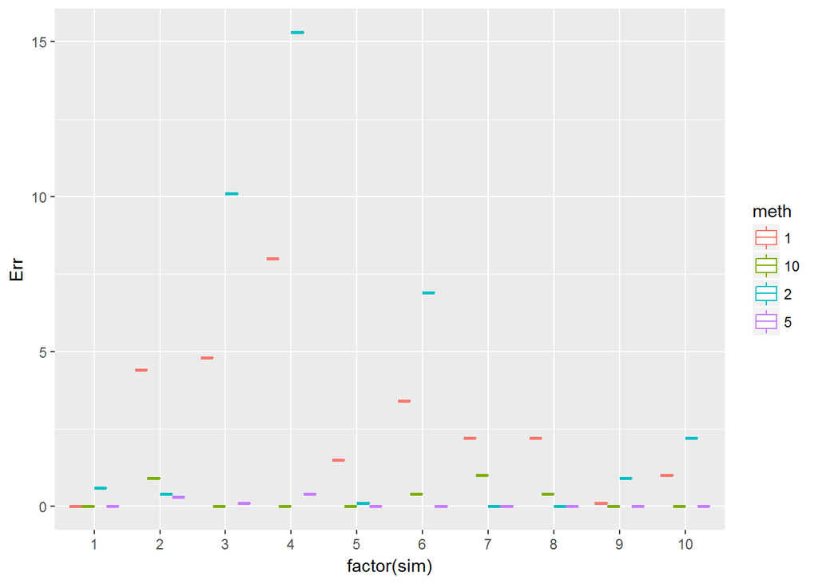

```r
library(ggplot2)
ggplot(knnTmpErr,aes(x=factor(sim),y=Err,colour=meth)) + geom_boxplot()
```

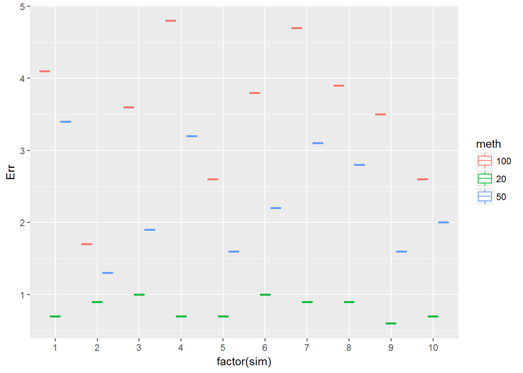

```r
ggplot(knnTmpErrsplit,aes(x=factor(sim),y=Err,colour=meth)) + geom_boxplot()
```

The above charts show Knn model for 10 sample data sets. To clearly separate the error rate for different K values, two charts are drawn. It can seen that the error rate is relatively higher for k=1, 2, 20,50 and 100. k =5 and k =10 relatively perform better.

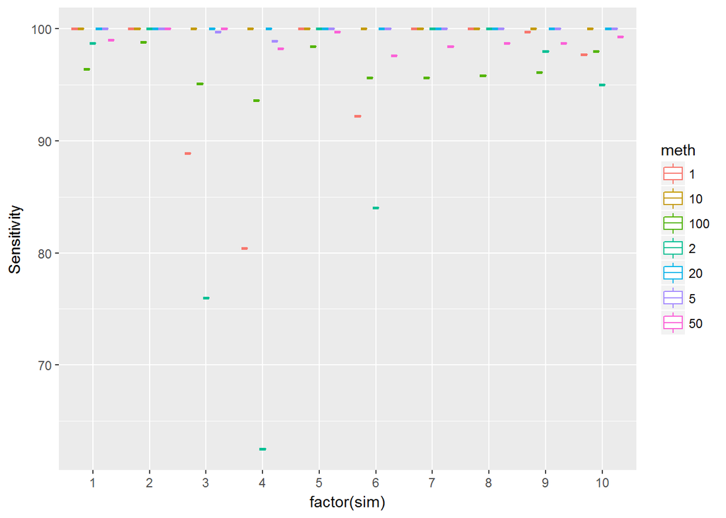

```r
ggplot(knnTmpSen,aes(x=factor(sim),y=Sensitivity,colour=meth)) + geom_boxplot()
```

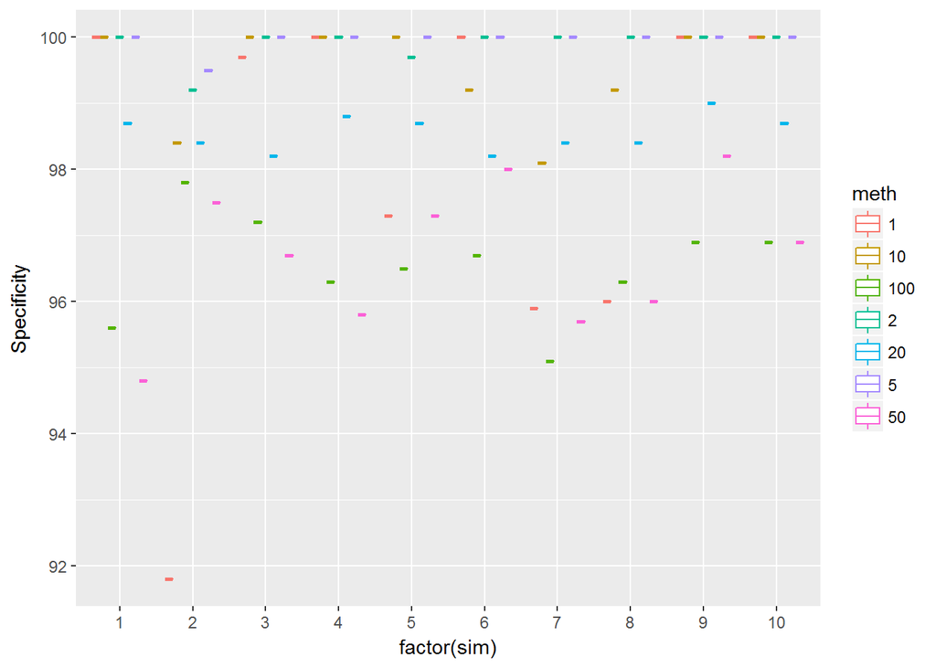

```r
ggplot(knnTmpSpe,aes(x=factor(sim),y=Specificity,colour=meth)) + geom_boxplot()
```

The above plots show Sensitiviy and Specificity for Knn method. Though it is a challenge to view the graph it can be said that the sensitivity and specificity are high for middle values of K = 5,10 and 20.

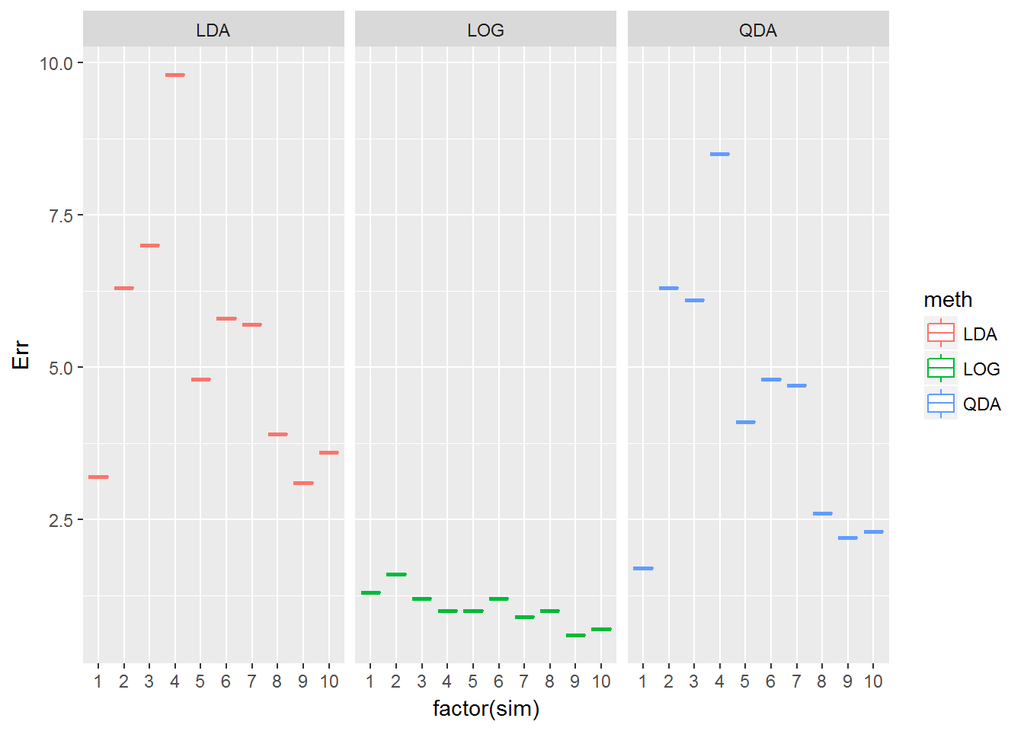

```r
ggplot(dfTmp,aes(x=factor(sim),y=Err,colour=meth)) + geom_boxplot()+facet_wrap(~meth)
```

The above graph shows Error rate for LDA, Logistic regression and QDA. Logistic regression has least error rate compared to LDA and QDA. But it is still higher than Knn with K =5 and 10.

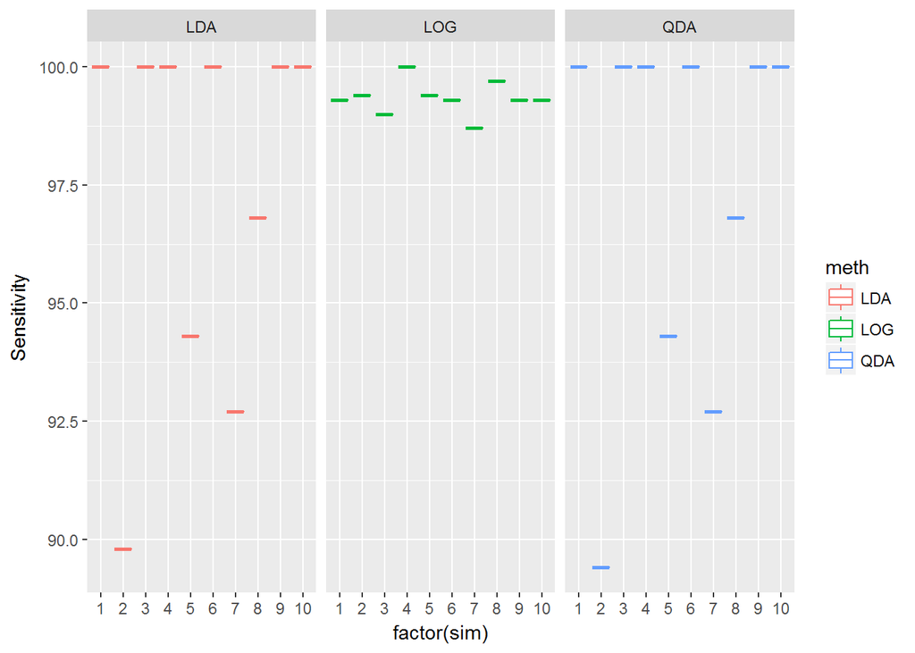

```r
ggplot(dfTmp1,aes(x=factor(sim),y=Sensitivity,colour=meth)) + geom_boxplot()+facet_wrap(~meth)
```

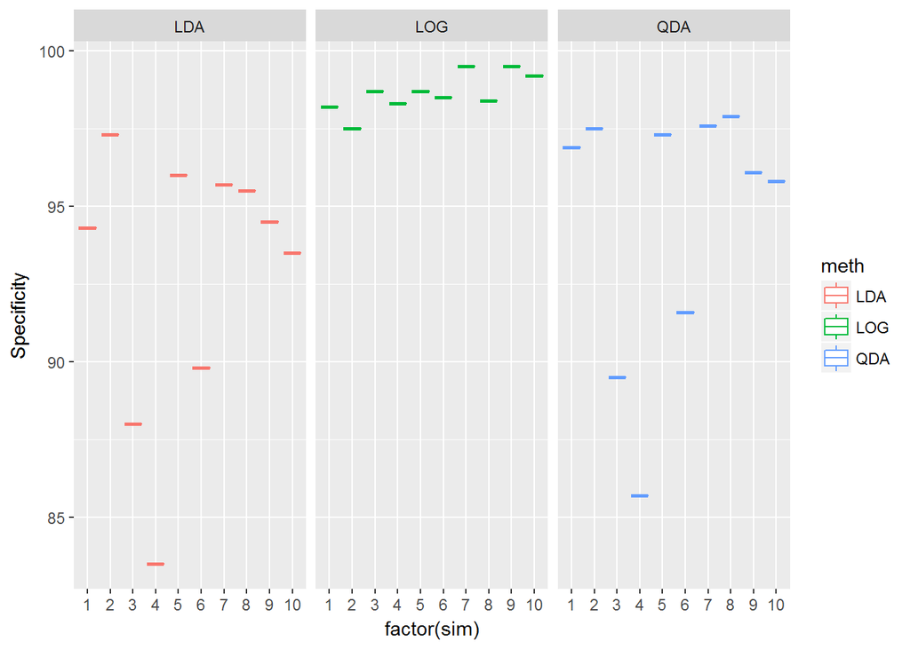

```r
ggplot(dfTmp2,aes(x=factor(sim),y=Specificity,colour=meth)) + geom_boxplot()+facet_wrap(~meth)
```